# The role of botanical gardens in climate change research - Primack - 2009 - New Phytologist - Wiley Online Library

[New Phytologist](https://nph.onlinelibrary.wiley.com/journal/14698137)

[Volume 182, Issue 2](https://nph.onlinelibrary.wiley.com/toc/14698137/2009/182/2) p. 303-313

[figure not shown]

Free Access

# The role of botanical gardens in climate change research

[Richard B. Primack](https://nph.onlinelibrary.wiley.com/authored-by/ContribAuthorRaw/Primack/Richard+B.),

[Abraham J. Miller-Rushing](https://nph.onlinelibrary.wiley.com/authored-by/ContribAuthorRaw/Miller%E2%80%90Rushing/Abraham+J.),

First published: 27 March 2009

https://doi.org/10.1111/j.1469-8137.2009.02800.x

Citations: 110

## Summary

Botanical gardens have a unique set of resources that allows them to host important climate change research projects not easily undertaken elsewhere. These resources include controlled growing conditions, living collections with broad taxonomic representation, meticulous record-keeping, networks spanning wide geographic areas, and knowledgeable staff. Indeed, botanical gardens have already contributed significantly to our understanding of biological responses to climate change, particularly the effects of temperature on the timing of flowering and leaf-out. They have also made significant contributions to the understanding of the relationships among climate, physiology, and anatomy. Gardens are finding new uses for traditional research tools such as herbarium specimens and historical photographs, which are increasingly being used to obtain information on past plant behavior. Additional work on invasive species and comparative studies of responses to climatic variation are providing insights on important ecological, evolutionary, and management questions. With their large collections of plant species from throughout the world and excellent herbaria, botanical gardens are well positioned to expand their current activities to continue to provide leadership in climate change research and education.

|  | Contents |  |
| --- | --- | --- |
|  | Summary | 303 |
| I. | Introduction | 303 |
| II. | The special resources of botanical gardens | 304 |
| III. | Phenology | 305 |
| IV. | Physiology and anatomy | 308 |
| V. | Invasive species and assisted migration | 309 |
| VI. | Comparative and phylogenetic studies | 310 |
| VII. | Conclusions | 311 |
|  | Acknowledgements | 312 |
|  | References | 312 |

## I. Introduction

Many recent changes in plant and animal behavior reflect the effects of global climate change. Biologists have observed birds migrating earlier in the spring (Lehikoinen *et al*., 2004; Gordo, 2007), declines in the sizes of some animal and plant populations (Moller *et al*., 2008; Willis *et al*., 2008), and plants, insects and other animals relocating to higher altitudes on mountain slopes and locations closer to the poles (Parmesan & Yohe, 2003). Some of the most convincing evidence of biological responses to climate change comes from work demonstrating changes in the flowering and leaf-out times of temperate and arctic plants, which are especially responsive to warm weather in the spring. The data on plant flowering and leaf-out are particularly compelling because they are abundant and because phenology is closely tied to climate (Root *et al*., 2003; Parmesan, 2007). Some of these data come from botanical gardens, where staff members have recorded the flowering and leafing dates of plants in their collections (Menzel & Fabian, 1999; Primack *et al*., 2004; Miller-Rushing *et al*., 2007).

Because of their large collections of plants from wide areas, botanical gardens are in a position to address many questions related to climate change research, often questions difficult to address at any other location. For example, how do long-lived individuals such as trees respond to changes in climate? Gardens often keep records of individually identifiable plants on their grounds, and often make observations on or collect material from those individuals annually or periodically through their lifetimes. These records can and have been used to track changes in the flowering, physiology, and anatomy of individual plants in response to changes in climate (Primack *et al*., 2004; Miller-Rushing & Primack, 2008a).

More generally, modeling studies have shown that as the climate changes some species will no longer be able to grow at their present locations because of a lack of temperature tolerance, water stress, competition with other plant species, or changes in patterns of herbivory (Iverson & Prasad, 1998; Thomas *et al*., 2004; Ibanez *et al*., 2006; Morin *et al*., 2007); such vulnerable species will either migrate or go extinct. Other species may maintain their present ranges but will change their behavior, leafing out earlier, flowering and fruiting earlier, and holding their leaves later in autumn. Which species will be vulnerable? Which will thrive? The behavior of plants in botanical gardens can provide insights into how species will respond in the wild. Horticulturists are already identifying certain drought- and temperature-sensitive species that are experiencing increased mortality rates in botanical gardens and those that are thriving under the changing conditions (Del Tredici, 2002).

The purpose of this paper is to highlight some of the important contributions that botanical gardens have already made to climate change research and to suggest further avenues of research that might be suitable for botanical gardens in coming years. Our review is not comprehensive, in part because many of the climate change-related activities of botanical gardens have not been published in the peer-review literature. Some projects have simply not been written about, while many others have just started. Additionally, there are future research opportunities beyond those we discuss here. However, we consider a broad range of roles for botanical gardens in climate change research.

## II. The special resources of botanical gardens

Botanical gardens have a combination of features that are unusual compared with other sites of long-term ecological and physiological work. Many of these features make them particularly good places for climate change research. First, the design of the grounds of botanical gardens generally mimics that of a common garden experiment, growing a wide variety of plant species together in one place under common conditions. Individual plants are often well spaced and grown under conditions considered ideal for their species. The grounds are often carefully mulched, weeded, fertilized, and kept free of pests. This level of care can create a reasonably consistent environment and reduce the number of factors that might alter long-term changes in plant traits.

Secondly, botanical gardens often grow many species together that could not be found growing together under natural conditions. These species have been collected from many different geographical areas of the world, and sometimes from places that have different climates from the botanical gardens where they are being grown. Thus, botanical garden collections can contain a taxonomically and ecologically diverse flora, often with extensive representation from particular genera or families. This diversity and depth of taxonomic representation facilitate comparative evolutionary, ecological, and phylogenetic studies (De Carvalho *et al*., 2004; DeBussche *et al*., 2004; Karlson *et al*., 2004; Miller-Rushing *et al*., 2007).

Thirdly, botanical gardens have long kept meticulous records (Dosmann, 2006). For example, the Royal Botanic Garden in Edinburgh and the Royal Botanic Gardens at Kew have records of plant phenology that date to the 19th century (Harper *et al*., 2004; Harper & Morris, 2007). Knowledge of phenological events, such as flowering times, allows garden staffs to inform visitors when certain popular species, such as daffodils, tulips, apple trees, cherry trees, lilacs and forsythias, will flower. These flowering records also facilitate the breeding of cultivars that flower at desirable times of year or that flower before or after their leaves emerge. Such records have been used to demonstrate that, for many species, spring flowering times and leafing out times are linked to temperature, and are now occurring earlier as a result of climate change (Menzel & Fabian, 1999; Chmielewski & Rotzer, 2001; Menzel *et al*., 2001; Harper & Morris, 2007). Other species have flowering times that are largely determined by day length or precipitation.

Gardens also often have records related to their horticultural and systematics research. These records include information on the tolerances of plants to various climatic conditions and large collections of herbarium specimens. Herbarium collections are a particularly rich source of historical records because they provide physical specimens that contain information about the phenology, nutrient content, health, and genetics of plants growing in nature or on garden grounds (Fig. 1). Sometimes, herbarium specimens can even be associated with the individual living plants from which they were collected. Gardens are also highly photogenic and often house extensive (and oft overlooked) collections of images. These images contain information about landscape characteristics, phenology, and the conditions and ages of plants on the grounds.

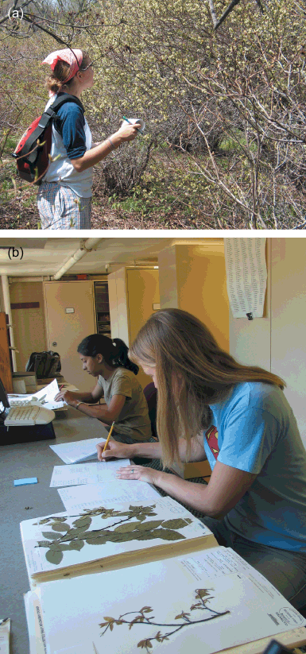

**Figure 1**

Open in figure viewer[PowerPoint](https://nph.onlinelibrary.wiley.com/action/downloadFigures?id=f1&doi=10.1111%2Fj.1469-8137.2009.02800.x)

Students (a) recording phenological observations and (b) examining herbarium specimens at the Arnold Arboretum of Harvard University.

Fourthly, botanical gardens form research networks spread across continents and the world (e.g. see section III. Phenology). In many cases, they grow the same plant species, sometimes even the same genetic stock, so that the characteristics of a species can be examined in a wide range of conditions. Where clones are grown across wide areas, researchers can isolate environmentally driven variation in species’ phenotypes, which can otherwise be difficult to separate from genetic effects.

The urban–rural gradient provides one intriguing example of the potential for botanical gardens to examine variation in plant responses to environmental conditions. Botanical gardens located in large urban areas have tended to warm more rapidly than surrounding areas because of the urban heat island effect. For example, from 1895 to 2000, mean annual temperatures at the Blue Hill Meteorological Observatory in Boston warmed 1.6°C, compared with a 0.7°C regional increase in temperature over the same time period (New England Regional Assessment Group, 2001). The increased warming in Boston is associated with more buildings, streets, parking lots and other human modifications. Because of this increased warming, botanical gardens in large cities can provide useful insights into the ecological changes that will occur in more rural areas as a result of future warming. Of course, urban areas also have more pollution and higher concentrations of various gases relative to rural areas, which may complicate the predictive value of urban gardens relative to rural gardens (Gregg *et al*., 2003). However, the effects of these other factors on many plant traits, such as phenology, generally appear to be minor relative to the effects of temperature, light, and precipitation (Cleland *et al*., 2006; Hovenden *et al*., 2008). Overall, networks of botanical gardens located in urban and rural areas provide an excellent opportunity to further examine climate-driven changes in plants.

Lastly, the staff members of botanical gardens are knowledgeable about plant identification, morphology, physiology, and ecology, because of their training and experience, which increases the reliability of their observations and makes them valuable members of interdisciplinary research teams. They are also in a special position to convey information about the impacts of climate change to the public in the form of displays for visitors, lectures, and articles in the popular press.

## III. Phenology

### Networks of botanical gardens

To examine the effects of climate change over large areas, many botanical gardens have worked together to make standard phenological observations of cloned plants growing on their grounds. Such networks complement the efforts of individual botanical gardens to investigate the impacts of climate change. The longest running and most comprehensive such effort is the International Phenological Gardens (IPG) project in Europe, founded in 1957, and now based at the Institute of Crop Sciences at Humboldt University in Berlin (Chmielewski, 1996; Menzel & Fabian, 1999; Menzel, 2000; Chmielewski & Rotzer, 2001) (Fig. 2). In this network, vegetatively propagated trees and shrubs have been planted at botanical gardens and other sites throughout Europe. The purpose of using cloned material is to reduce the amount of genetic variation, so that variation in phenology reflects the influence of environmental factors rather than genetic differences among individuals.

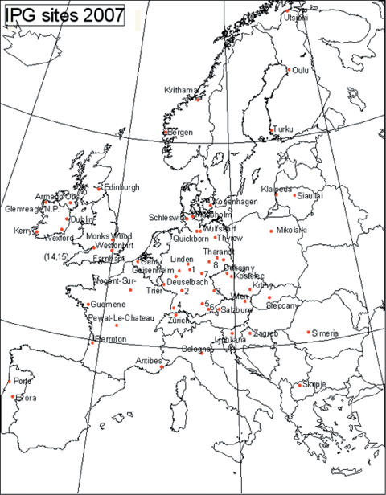

**Figure 2**

Open in figure viewer[PowerPoint](https://nph.onlinelibrary.wiley.com/action/downloadFigures?id=f2&doi=10.1111%2Fj.1469-8137.2009.02800.x)

Map of botanical gardens and other sites in Europe participating the International Phenological Gardens (IPG) project. From the IPG website (http://www.agrar.hu-berlin.de/struktur/institute/pfb/struktur/agrarmet/phaenologie/ipg/).

The IPG first began to record phenology in 1959, and its records now include *c*. 65 000 observations of 23 plant species at *c*. 50 botanical gardens across Europe (Menzel, 2003) (Fig. 2). Species such as European white birch (*Betula pubescens*), sweet cherry (*Prunus avium*), European rowan or mountain ash (*Sorbus aucuparia*), and alpine currant (*Ribes alpinum*) have been particularly well observed. Observers record the timing of leaf unfolding, flowering, fruit ripening, leaf coloring, and leaf fall. This project has shown that the species they examined are now flowering and leafing out on average of 6.3 d earlier in the spring than 50 yr ago. By contrast, autumn events, such as leaf coloring and leaf fall, are occurring 4.5 d later than in the past (Menzel & Fabian, 1999). The net result is that the growing season for these species has grown *c*. 11 d longer over the past 50 yr. Intriguingly, researchers also noticed that changes in the timing of spring events seem to differ among species more than do events occurring in the late summer and autumn (Menzel, 2000). Also, shrubs seem to be more responsive to changes in temperature than do trees (Menzel, 2000). There are regional differences as well, with greater changes in spring phenological events in northern Europe than in southeastern Europe (Menzel, 2000).

The records of the IPG have now been combined with a large set of observations throughout Europe that includes the phenological trends of 542 plant species and 19 animal species from 21 countries, for a total of 125 000 series of observations (Menzel *et al*., 2006). These results further demonstrate that the spring phenologies of many plant species are advancing, and that this advance is strongly correlated with warming temperatures. Further, the timing of spring phenological events has advanced most in the countries where temperatures have warmed the most (Menzel *et al*., 2006) – that is, the spatial patterns of phenological change matched spatial patterns of warming – providing particularly compelling evidence that changes in climate are driving the changes in phenology.

### Phenological gardens

In addition to the efforts of networks of botanical gardens, a number of research projects have been developed in which the same species or even cultivars have been grown over a wide area, including but not confined to botanical gardens, to facilitate standard phenological observations. Plantings of these standard plants are termed phenological gardens.

The most comprehensive attempts to correlate weather and flowering times in North America were made by regional networks of phenological gardens between 1957 and 1994 (Schwartz, 1994; Cayan *et al*., 2001; Schwartz & Beaubien, 2003). The networks spanned the USA, eventually involving 2000 observers, including US Department of Agriculture staff and private citizens, who monitored the behavior of common lilac (*Syringa vulgaris*) and three designated cultivars: one of the Chinese lilac *Syringa*×*chinensis*‘Red Rothomagensis’, and two honeysuckles, *Lonicera tartarica*‘Arnold Red’ and *Lonicera korolkowii* var. *zebelli*. Observers were given specific instructions on how to record the dates of leaf-out, first flowering, peak flowering, and flower withering. These records have shown that plants across the USA are now flowering *c*. 1 wk earlier than in the 1950s, when the observations began (Cayan *et al*., 2001; Wolfe *et al*., 2005). The data also showed a high degree of correlation among the various phenological events – for example, in years with earlier first flowering, leaf-out also occurred earlier – indicating that the events are developmentally linked (Schwartz & Reiter, 2000). The regional network projects eventually ended as a consequence of lack of permanent institutional backing, but parts of the networks have now been revitalized and have become part of the USA National Phenology Network (USA-NPN) (Schwartz & Beaubien, 2003).

With recently renewed interest in phenology related to climate change, projects are currently underway to establish new networks of citizen observers and phenological gardens, many involving and based at botanical gardens both in the USA and in Europe (van Vliet *et al*., 2003; Betancourt *et al*., 2005). By encouraging citizens to monitor phenology gardens, common cultivated plants, and wild species, researchers hope to increase our understanding of climate-driven changes in phenology, particularly variation across geographical regions and among species, beyond what botanical garden staff and professional observers could accomplish alone. These phenology gardens can also be combined with pollinator gardens, offering the opportunity to track changes in the relationships between plants and pollinators. A secondary (sometimes primary) goal of many phenological gardens is to involve the general public in scientific research so that they become more supportive of scientific research and more knowledgeable about the scientific process in general and the issues of climate change in particular (van Vliet *et al*., 2003; Betancourt *et al*., 2005).

### Herbarium specimens

Although direct observations of plant phenology at botanical gardens have proved valuable for understanding how certain plants in certain places respond to climatic variation, there are many places and time periods for which data are lacking. To build a more geographically complete picture, scientists must seek new sources of data (Sparks, 2007), some of which are held by botanical gardens. In particular, herbarium collections could provide valuable tools for studying plants’ responses to climate change.

Consider the example of the Arnold Arboretum of Harvard University, located in Boston. Over its 120-yr history, the Arnold Arboretum did not systematically collect phenological data. However, the arboretum has collected herbarium specimens for well over 100 yr. The Arnold Arboretum Herbarium in Jamaica Plain holds a collection of ~150 000 dried plant specimens, many of which were taken from the arboretum's living collections as part of a standard documentation process. The record label that accompanies each dried and pressed specimen includes the name of the species, the identification number of the plant, and the date of collection, and – importantly – a visual examination of the plant shows the phenological state of the plant, such as flowering, past flowering, or in fruit. Many of the plants from which the specimens were taken are among the 15 000 plants still growing on the grounds of the Arnold Arboretum. By combining the information from herbarium specimens on when plants flowered in the past with information on when plants are flowering in present years, one can show the responses of plants to changing climatic conditions (Primack *et al*., 2004; Miller-Rushing *et al*., 2006).

A potential criticism of using herbarium specimens to study phenology involves the uncertainty as to when a specimen was collected during a particular phenological phase. For example, it is difficult or impossible to know whether a flowering specimen was collected near the beginning, peak, or end of a flowering season. For species with long flowering durations, this could be a very real problem. However, we and others have shown that with a large enough sample size herbarium specimens can provide a reasonable estimate of peak flowering date, particularly for species with relatively short flowering durations (e.g. 1 or 2 wk) (Primack *et al*., 2004; Bolmgren & Lonnberg, 2005). The peak flowering date is a particularly useful measure of flowering time, because it is generally not influenced by population size (or plant size if a single plant is being monitored). First flowering date, the measure often used in phenological studies, is influenced by population size (and plant size), making it difficult to separate climate-driven changes from population size-driven (and plant size-driven) changes (Miller-Rushing *et al*., 2008). Additional work has shown that herbarium specimens can also be used to analyze the relationship between phenology and climate in arid areas where plants tend to have much longer flowering durations (Bowers, 2007). Together, studies of herbarium specimens have shown the close link between temporal and spatial variation in flowering times and climate (Lavoie & Lachance, 2006), and have also elucidated connections among phylogeny, plant traits, and phenology (Bolmgren & Lonnberg, 2005).

### Photographs

Photographs provide another source of data for measuring changes in plant flowering times and other phenological events. Like herbarium specimens, dated photographs of plants in flower provide an estimate of the peak flowering date of an individual (Miller-Rushing *et al*., 2006). Combining an analysis of dated photographs with current observations can be an effective way to examine whether plants are now flowering earlier than in the past, and the degree to which flowering times are affected by temperature (Miller-Rushing *et al*., 2006). Photographs also are sometimes more common than herbarium specimens or observations collected by individual scientists. Collections of photographs that include plants in flower can be found in botanical gardens, museums, libraries, universities, or private holdings. Other fields of science have used abundant photographic records to document changes in soil and vegetation and to calculate the rate of retreat of glaciers (Harrison, 1974; Rogers *et al*., 1984; Trimble & Crosson, 2000). Sparks *et al*. (2006) used fixed-date photographs to document changes in plant development in response to weather conditions in particular years.

Photographs also have a great ability to convey the story of climate change in pictorial form. For example, we obtained a striking photograph taken in the Lowell Cemetery in Lowell, Massachusetts, on Memorial Day, 30 May 1868 (Miller-Rushing *et al*., 2006) (Fig. 3). In the photo, the trees have not leafed out yet, despite the late date, or the leaves have been damaged by a late frost. In addition, people are wearing heavy clothing. A photograph taken on the same date in 2005 at the same location shows that the trees are fully leafed out. The mean temperature from February to May of 1868 was 2.2°C lower than the average over the past 150 yr and 2.7°C colder than February–May 2005. Similar pairs or series of photographs of the same location can create compelling visual evidence of the effects of climate change that resonates strongly with the media and the public (Miller-Rushing *et al*., 2006).

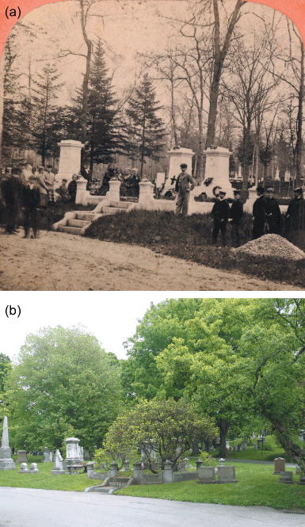

**Figure 3**

Open in figure viewer[PowerPoint](https://nph.onlinelibrary.wiley.com/action/downloadFigures?id=f3&doi=10.1111%2Fj.1469-8137.2009.02800.x)

(a) A picture of the Lowell Cemetery in Lowell, Massachusetts, USA taken on 30 May 1868, a relatively cold year, in which the leaves are not yet out. (b) The same scene taken on 30 May 2005, a relatively warm year, in which the leaves are already flushed out. From Miller-Rushing *et al*. (2006), with permission from the *American Journal of Botany*.

## IV. Physiology and anatomy

Botanical gardens can further contribute to climate change research through investigations of the physiological and anatomical characteristics of plants that make them more or less susceptible to the effects of climate change, and through studies of plastic responses of plants to changes in climate. Researchers can investigate various species’ response to drought, high temperatures, winter thaws, and frost.

In a practical way, staff members could identify those species that used to grow well at a botanical garden and are apparently not able to adapt to new climatic conditions. For example, certain cool-climate species may show new signs of summer heat and drought stress that had not been apparent in the past. Staff members could also identify those warm-climate species that used to be difficult to grow at a site and now seem to be growing more vigorously and with less need for support (Del Tredici, 2002). A species that previously needed special treatment to survive the winter cold, such as being put into a cold frame, perhaps can now survive outside on its own. Botanical garden staffs make these kinds of observations all the time, as a routine matter of maintaining their living collections. Such plant responses have already been noted at many botanical gardens (S. Renner, pers. comm.) For example, the mock strawberry (*Duchesnea indica*) had previously only survived winters in Bavaria in the glasshouse; but now the species is escaping from cultivation and surviving outside all year round. Once species’ responses to a changing climate are identified – whether the response is in terms of growth, flower production, phenology, winter die-back, or general vigor – it is possible to investigate particular traits associated with the response using a comparative or experimental method.

The abundant research on cold tolerance in a variety of species provides excellent examples of how the living collections of gardens and arboreta can be used to investigate physiological responses to climate change. In one such example, researchers investigated the mechanisms regulating the onset of seasonal cold tolerance in some species of dogwoods (*Cornus*) (Sarnighausen *et al*., 2002; Karlson *et al*., 2003). They found that shortening days are critical for the reduction of stem water content and the accumulation of dehydrin-like proteins, which help the plants tolerate freezing temperatures (Karlson *et al*., 2003). Taking particular advantage of botanical garden and arboretum resources, the investigators expanded their work and explored the evolutionary history of mechanisms of cold tolerance across the genus (Karlson *et al*., 2004). They studied plant material collected from 31 species of *Cornus* and found that a single group of species within the genus evolved to use dehydrin-like proteins to tolerate freezing, rather than use the ancestral method of supercooling to avoid freezing, the method used by other species within the genus (Karlson *et al*., 2004). The shift to freezing tolerance appears to have allowed this group of species to expand their ranges farther northward than the supercooling species (Karlson *et al*., 2004). Studies like these investigating physiological interactions with climatic conditions have added importance in the context of climate change and will help us to model shifts in species’ persistence, ranges, and evolutionary responses to the changing climate.

Other studies at botanical gardens can examine the plastic responses of individuals to changes in climate or concentrations of various gases, such as carbon dioxide (CO<sub>2</sub>). For example, leaf stomata are an important anatomical characteristic linked to the physiology of plants. There is evidence that plant populations respond to increasing concentrations of CO<sub>2</sub> by producing leaves with fewer stomata per unit area (Woodward, 1987; Beerling, 1996; Hetherington & Woodward, 2003). For periods of over 100 yr, this pattern seems consistent across species, but for periods of fewer than 100 yr, the results are mixed (Royer, 2001). Additionally, it is not well known how the leaf anatomies of individuals, rather than populations, respond over periods of 5–100 yr of changing climatic and atmospheric conditions (Royer, 2001). Herbarium specimens from botanical gardens can help to fill these gaps in our knowledge by providing information on the size and abundance of stomata on leaf surfaces in individuals or populations over time (Penuelas & Matamala, 1990). It is a straightforward technique to make casts of the leaf undersurface using clear nail polish, or other similar material, from which to measure the density and size of stomata (Fernandez *et al*., 1998; Miyazawa, 2005). Leaf peels do not damage the specimen and will work for almost any specimen where leaf undersurfaces are exposed or are readily accessible, except for leaves that are excessively hairy. Researchers can compare herbarium specimens collected decades or centuries ago to herbarium specimens collected more recently or even collected from living trees on the grounds of botanical gardens. Given sufficient sample sizes, scientists can determine whether stomatal densities and sizes are changing, and if so, whether they are responding to higher temperatures, changes in soil moisture, or higher concentrations of CO<sub>2</sub> (Penuelas & Matamala, 1990).

Leaves from herbarium specimens and from living trees can also yield information on water use efficiency (WUE), photosynthesis, and stomatal conductance through analyses of stable isotopes (Penuelas & Azconbieto, 1992). WUE – the amount of photosynthetic CO<sub>2</sub> fixation per unit of transpirational water loss (*A*/*E*) – generally increases as plants are exposed to higher concentrations of CO<sub>2</sub> (Tricker *et al*., 2005; Ainsworth & Rogers, 2007). Researchers can estimate WUE by using mass spectrometry to measure the ratio of stable isotopes of carbon and oxygen in leaf fragments. When a plant is not under water stress, it preferentially absorbs CO<sub>2</sub> with <sup>12</sup>C rather than <sup>13</sup>C during photosynthesis. However, when the plant is under water stress the proportion of <sup>12</sup>C it absorbs more closely matches the atmospheric concentration (i.e. a higher proportion of <sup>13</sup>C). By examining herbarium specimens collected over time from individually marked trees growing on the grounds of a botanical garden and measuring the relative concentrations of stable isotopes of carbon, it would be possible to determine whether WUE (or intrinsic WUE) has changed over time (Penuelas & Azconbieto, 1992). Stable oxygen isotopes allow researchers to further attribute changes in WUE to either photosynthesis or stomatal conductance (Sullivan & Welker, 2007). Water and light conditions can alter WUE responses to climate change and increasing concentrations of CO<sub>2</sub>, making it important that researchers using gardens for these studies account for watering schedules and the canopy positions from which leaves are collected whenever possible. Other physiological characteristics using stable isotopes are now being developed. One disadvantage of measuring stable isotopes in herbarium specimens is that the method involves some destructive sampling of leaf material, although typically only a small part of a leaf.

## V. Invasive species and assisted migration

Botanical gardens often stretch the limits of species ranges, trying to grow plants in locations beyond their natural distributions. This feature of gardens makes them particularly well suited to investigate issues related to the limits of these ranges. Here we discuss their potential role in studies of climate-facilitated species invasions and assisted migration.

Botanical gardens are frequently leaders in the importation of new plants species, and their subsequent release into cultivation. As such, botanical gardens can take credit for much of the beautification of our towns, parks, and lawns, many improvements in cultivated plants, and the discovery of new medicinal plants. Many of the trees, shrubs, and vines planted along streets, in front of houses, and in our city parks were collected and first grown by botanical gardens and then later distributed by the botanical gardens themselves or through commercial nurseries. In addition to this generally positive role, botanical gardens and associated commercial nurseries have played a sometimes unfortunate role in the release of new plant diseases and insect pests (Dawson *et al*., 2008; Van der Veken *et al*., 2008). Further, botanical gardens are often a focal point for the spread of imported plant species, some of which have the potential to become invasive, into natural areas (Dawson *et al*., 2008). Staff members working at botanical gardens often observe that certain species planted on the grounds show special abilities to mature large crops of seeds, which are then readily dispersed into the surrounding habitat, and the seeds then have the ability to germinate and produce vigorously growing plants. Other species have the ability to spread via rhizomes or other means of vegetative propagation. This type of spread of imported species has been going on for hundreds of years in botanical gardens throughout the world.

In recent years, however, warming temperatures, changing patterns of precipitation, and other aspects of climate change are creating conditions that allow new species to survive and become invasive in the wild (Dukes & Mooney, 1999). A notable example of this is the recent spread of exotic evergreen species in areas of Switzerland caused by a warming climate (Walther, 2002). The recent dramatic increases in the abundance of garlic mustard (*Alliaria officinalis*) and black swallowwort (*Cynanchum nigrum*) in eastern North America may provide two additional examples. Botanical gardens have the potential to monitor their collections for the increased ability of introduced species to reproduce and become invasive. Many gardens have already instituted weed risk assessments (Jefferson *et al*., 2004; Caley *et al*., 2006), which are constantly improving and may be modified to investigate the ability of species to become invasive as climatic conditions change.

Unlike invasive species, which have rapidly expanding ranges, conservation biologists are concerned about how to manage rare or endangered species in the face of climate change. These species are often poor dispersers and may not be able to move fast enough to keep up with changing climatic conditions. Managers and conservation biologists are currently debating the advisability and feasibility of moving species into new regions as climate changes, or even in anticipation of further climate changes. This type of intentional transplantation of species has been termed assisted migration (McLachlan *et al*., 2007). Because of their experience in transplanting and growing species beyond their natural ranges, botanical gardens can provide an ideal testing ground for assisted migrations. In addition, gardens are uniquely suited to address a major concern regarding assisted migrations – the threat that transplanted species may become invasive or otherwise disrupt ecological relationships and processes – by incorporating these species into their weed risk assessments. By evaluating the success of transplanted species, researchers could gain considerable insight into the likelihood that a species would establish in the wild and the likelihood that it would become a nuisance species.

## VI. Comparative and phylogenetic studies

A great advantage of botanical gardens is that numerous species in the same taxonomic group – for example, pines or rhododendrons – grow in the same environmental conditions. Even though these species are not growing in their original locations and growing conditions, it is still possible to observe how they respond to the environmental variation. If closely related species respond to climate change in similar ways, this will simplify predictions of the ecological impacts of climate change. However, if closely related species differ significantly in their responses to climate change, as some studies suggest (Fitter & Fitter, 2002; Miller-Rushing & Primack, 2008b), then we may need to examine the effects of climate change on each particular species. It is also possible that the responses of closely related species may differ in some predictable manner. Only after comparative studies are carried out will we be able to adequately predict phenological changes and their effects on community structure, ecosystem dynamics, and population processes.

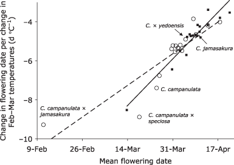

**Figure 4**

Open in figure viewer[PowerPoint](https://nph.onlinelibrary.wiley.com/action/downloadFigures?id=f4&doi=10.1111%2Fj.1469-8137.2009.02800.x)

Variation in flowering response of cherry trees (*Cerasus* or *Prunus*) to February–March temperatures explained by mean flowering date. Each point represents one taxon. Closed squares and the solid line represent peak flowering observations. Open circles and the dashed line represent first flowering observations. Lines represent best-fit linear regressions. The points for first flowering are labeled for some notable species. For peak flowering *R*<sup>2</sup> = 0.904, *P* < 0.001; for first flowering *R*<sup>2</sup> = 0.775, *P* < 0.001. From Miller-Rushing *et al*. (2007), with permission from the *American Journal of Botany*.

Given the breadth of diversity represented at botanical gardens, it is also possible to use phylogenetic approaches to examine plant responses to climate change. These approaches, which include the evolutionary history of the species as a covariate, are now being successfully applied to natural floras to explore the relationship between the responses of plants to climate change and shifts in the abundance of species (Willis *et al*., 2008). Many projects at gardens and arboreta are already investigating phylogenetic relationships within particular plant groups (Li *et al*., 2005; Oh & Potter, 2005). Similar techniques could be applied at botanical gardens to evaluate traits associated with particular responses of species to climate change (see section IV. Physiology and anatomy), where researchers could have much more diverse groups of species with which to work than would occur naturally. For example, Karlson *et al*. (2004) used phylogenetic methods to investigate the evolutionary history of cold tolerance mechanisms in *Cornus*. By including phylogenetic analyses in studies like this example, researchers could gain further insights into ecological and evolutionary patterns.

## VII. Conclusions

The evidence reviewed here shows that botanical gardens can serve as particularly valuable sources of long-term data to describe how plants are responding to climate change. Gardens have a unique combination of resources that make them particularly well placed to answer certain questions concerning plant responses to climate change. Researchers at botanical gardens can address questions of how individual, long-lived plants respond to climate change over their lifetimes in terms of phenology, physiology, growth, and anatomy. The diversity of botanical garden collections can also yield insights into phylogenetic patterns of species’ responses to climatic variation and the mechanisms driving those patterns. The opportunities for advancing our knowledge abound.

We particularly hope that botanical gardens maintain their tradition of excellent record keeping. For example, because of the sensitivity of plant phenological events to climate change, the importance of phenological events such as flowering, and the relative ease of making phenological observations, we strongly suggest that botanical gardens actively collect phenological data on plants in their collections. Many are already doing so. Under ideal circumstances, botanical garden staff could make direct observations of key phenological events such as leaf bud burst, flowering, fruiting, leaf color changes and leaf senescence, using the methods of the IPG, USA-NPN, or one of the many other phenological organizations. If staff time were limited, even sampling just once or twice a week for a few key species and life stages would be sufficient to provide valuable information. Other methods of record keeping, however, such as the regular collection of herbarium specimens and photographs, can also provide valuable information showing phenological, physiological, and anatomical responses to climate change.

Moreover, because of the controlled growing conditions and taxonomic representation, research at botanical gardens is particularly well situated to move beyond simply evaluating species responses to climate change. They can allow researchers to evaluate the evolutionary histories of those responses and improve our predictions of how various species will respond to future climate change. This work can help us to identify which species will thrive under changing climate conditions and which may be conservation priorities, among the most pressing climate-related questions in ecology.

Of special concern, we suggest that species be monitored to determine whether previously hardy species are no longer able to grow at particular botanical gardens. Additionally, researchers should note species that were previously difficult to grow at a site that are able to thrive in the changing climatic conditions. Most gardens are already making these observations, and such information, when widely publicized, can have practical value to landscape designers, urban planners, and the general public in making good decisions when selecting species to plant. Further, these insights from gardens can provide predictions for changes that may occur in the wild.

Lastly, we emphasize that botanical gardens have a special role to play in informing the public about the impact of climate change on plants. People want to know how climate change is affecting the plants we need for food and those we use to improve the aesthetics of our surroundings. People also want to know how climate change is impacting the wild species that contribute to the biodiversity of our environment. Botanical gardens, which often have combined missions of education and research, will be especially effective at educating the public about this topic if they can use research examples from their own collections in their exhibits and presentations.

## Acknowledgements

We would like to express our appreciation to Boston University, the Arnold Arboretum of Harvard University, the University of Tokyo, and the National Science Foundation for their support of various projects described in this article. The staff of the Arnold Arboretum, in particular, have provided many valuable suggestions and opportunities. We thank Peter Del Tredici, Michael Dosmann, Elizabeth Ellwood, Kay Havens, Caroline, Polgar, Susanne Renner, David Roberts, and three anonymous reviewers for providing valuable comments on earlier versions of this manuscript.

## Citing Literature

[Volume182, Issue2](https://nph.onlinelibrary.wiley.com/toc/14698137/2009/182/2)

April 2009

Pages 303-313

[figure not shown]